# Entrega 1 - Notebook Reproducible

2025-09-17

# 1 1. Carga de Librerías

```r
suppressPackageStartupMessages({
  library(tidyverse)
  library(janitor)
  library(psych)
  library(readr)
  library(kableExtra)
  library(corrplot)
  library(rstatix)
  library(effectsize)
  library(patchwork)
})
render_table <- function(data, caption = NULL, html_font_size = 10, ...) {
  tab <- knitr::kable(data, caption = caption, ...)
  if (knitr::is_html_output()) {
    tab <- kableExtra::kable_styling(tab, font_size = html_font_size)
  }
  tab
}
```

# 2 2. Carga y Exploración Inicial de Datos

```r
# Carga reproducible (ruta relativa)
df <- read_csv("/Users/thom/Library/Mobile Documents/com~apple~CloudDocs/Universidad/Proba 2/Probability-Proyect/data/health_lifestyle_classification.csv", show_col_types = FALSE) %>% clean_names()
cat("Filas:", nrow(df), " - Columnas:", ncol(df), "\n")
```

```
## Filas: 100000  - Columnas: 48
```

```r
str(df, give.attr = FALSE)
```

```
## spc_tbl_ [100,000 × 48] (S3: spec_tbl_df/tbl_df/tbl/data.frame)
##  $ survey_code             : num [1:100000] 1 2 3 4 5 6 7 8 9 10 ...
##  $ age                     : num [1:100000] 56 69 46 32 60 25 78 38 56 75 ...
##  $ gender                  : chr [1:100000] "Male" "Female" "Male" "Female" ...
##  $ height                  : num [1:100000] 173 163 177 172 164 ...
##  $ weight                  : num [1:100000] 56.9 97.8 80.7 63.1 40 ...
##  $ bmi                     : num [1:100000] 18.9 36.7 25.7 21.3 14.9 ...
##  $ bmi_estimated           : num [1:100000] 18.9 36.7 25.7 21.3 14.9 ...
##  $ bmi_scaled              : num [1:100000] 56.7 110.1 77 64 44.8 ...
##  $ bmi_corrected           : num [1:100000] 19 36.5 25.6 21.2 14.8 ...
##  $ waist_size              : num [1:100000] 72.2 85.6 90.3 100.5 69 ...
##  $ blood_pressure          : num [1:100000] 118 118 123 148 151 ...
##  $ heart_rate              : num [1:100000] 60.7 66.5 76 68.8 92.3 ...
##  $ cholesterol             : num [1:100000] 215 116 138 203 200 ...
##  $ glucose                 : num [1:100000] 103 116.9 89.2 128.4 94.8 ...
```

[output cut: 34 more lines]

```r
missing_tbl <- df %>% summarise(across(everything(), ~sum(is.na(.)))) %>% pivot_longer(everything(), names_to = "variable", values_to = "na") %>% mutate(pct = round(100*na/nrow(df),2)) %>% arrange(desc(pct))
missing_tbl %>%
  head(15) %>%
  render_table(col.names = c("Variable","NA","%NA"), caption = "Top 15 variables con mayor NA", html_font_size = 10)
```

Top 15 variables con mayor NA

| Variable | NA | %NA |
| --- | --- | --- |
| insulin | 15836 | 15.84 |
| heart_rate | 14003 | 14.00 |
| alcohol_consumption | 13910 | 13.91 |
| gene_marker_flag | 10474 | 10.47 |
| income | 8470 | 8.47 |
| daily_steps | 8329 | 8.33 |
| blood_pressure | 7669 | 7.67 |
| survey_code | 0 | 0.00 |
| age | 0 | 0.00 |
| gender | 0 | 0.00 |
| height | 0 | 0.00 |
| weight | 0 | 0.00 |
| bmi | 0 | 0.00 |
| bmi_estimated | 0 | 0.00 |
| bmi_scaled | 0 | 0.00 |

# 3 3. Tipología de Variables

```r
chr_vars <- names(df %>% select(where(is.character)))
num_vars <- names(df %>% select(where(is.numeric)))
list(chr_vars = chr_vars[1:20], num_vars = num_vars[1:20])
```

```
## $chr_vars
##  [1] "gender"                "sleep_quality"         "alcohol_consumption"
##  [4] "smoking_level"         "mental_health_support" "education_level"
##  [7] "job_type"              "occupation"            "diet_type"
## [10] "exercise_type"         "device_usage"          "healthcare_access"
## [13] "insurance"             "sunlight_exposure"     "caffeine_intake"
## [16] "family_history"        "pet_owner"             "target"
## [19] NA                      NA
##
## $num_vars
##  [1] "survey_code"       "age"               "height"
##  [4] "weight"            "bmi"               "bmi_estimated"
##  [7] "bmi_scaled"        "bmi_corrected"     "waist_size"
## [10] "blood_pressure"    "heart_rate"        "cholesterol"
## [13] "glucose"           "insulin"           "sleep_hours"
## [16] "work_hours"        "physical_activity" "daily_steps"
## [19] "calorie_intake"    "sugar_intake"
```

# 4 4. Marco Metodológico Completo

## 4.1 Origen de los Datos

Los datos provienen del dataset “Health Lifestyle Classification” que contiene información recolectada sobre hábitos de salud y estilo de vida. El dataset incluye variables demográficas, biométricas, de comportamiento, salud mental y socioeconómicas recopiladas mediante encuestas estructuradas.

## 4.2 Objetivo del Análisis

Caracterizar los patrones de salud y estilo de vida en la población estudiada mediante técnicas de estadística descriptiva e inferencial, específicamente: 1. Describir distribuciones univariadas y bivariadas 2. Identificar relaciones entre variables 3. Evaluar si el BMI promedio poblacional difiere de 25 kg/m² 4. Determinar si la proporción de individuos saludables difiere del 50%

# 5 5. Análisis Descriptivo de Variables Categóricas

```r
cat_vars <- chr_vars
cat_summary <- map_df(cat_vars, ~df %>% count(.data[[.x]]) %>% mutate(variable = .x) %>% rename(valor = 1, frecuencia = n))
cat_summary %>%
  group_by(variable) %>%
  mutate(pct = round(100*frecuencia/sum(frecuencia),2)) %>%
  ungroup() %>%
  head(40) %>%
  render_table(caption = "Frecuencias (primeras 40 filas)", html_font_size = 10)
```

Frecuencias (primeras 40 filas)

| valor | frecuencia | variable | pct |
| --- | --- | --- | --- |
| Female | 49868 | gender | 49.87 |
| Male | 50132 | gender | 50.13 |
| Excellent | 25091 | sleep_quality | 25.09 |
| Fair | 25008 | sleep_quality | 25.01 |
| Good | 25147 | sleep_quality | 25.15 |
| Poor | 24754 | sleep_quality | 24.75 |
| None | 28477 | alcohol_consumption | 28.48 |
| Occasionally | 28831 | alcohol_consumption | 28.83 |
| Regularly | 28782 | alcohol_consumption | 28.78 |
| NA | 13910 | alcohol_consumption | 13.91 |
| Heavy | 33208 | smoking_level | 33.21 |
| Light | 33437 | smoking_level | 33.44 |
| Non-smoker | 33355 | smoking_level | 33.35 |
| No | 50104 | mental_health_support | 50.10 |
| Yes | 49896 | mental_health_support | 49.90 |
| Bachelor | 25363 | education_level | 25.36 |
| High School | 25028 | education_level | 25.03 |
| Master | 24992 | education_level | 24.99 |
| PhD | 24617 | education_level | 24.62 |
| Healthcare | 16546 | job_type | 16.55 |
| Labor | 16777 | job_type | 16.78 |
| Office | 16704 | job_type | 16.70 |
| Service | 16571 | job_type | 16.57 |
| Tech | 16691 | job_type | 16.69 |
| Unemployed | 16711 | job_type | 16.71 |
| Artist | 16657 | occupation | 16.66 |
| Doctor | 16927 | occupation | 16.93 |
| Driver | 16562 | occupation | 16.56 |
| Engineer | 16474 | occupation | 16.47 |
| Farmer | 16719 | occupation | 16.72 |
| Teacher | 16661 | occupation | 16.66 |
| Keto | 24764 | diet_type | 24.76 |
| Omnivore | 25089 | diet_type | 25.09 |
| Vegan | 25122 | diet_type | 25.12 |
| Vegetarian | 25025 | diet_type | 25.02 |
| Cardio | 24988 | exercise_type | 24.99 |
| Mixed | 24778 | exercise_type | 24.78 |
| None | 24969 | exercise_type | 24.97 |
| Strength | 25265 | exercise_type | 25.26 |
| High | 33562 | device_usage | 33.56 |

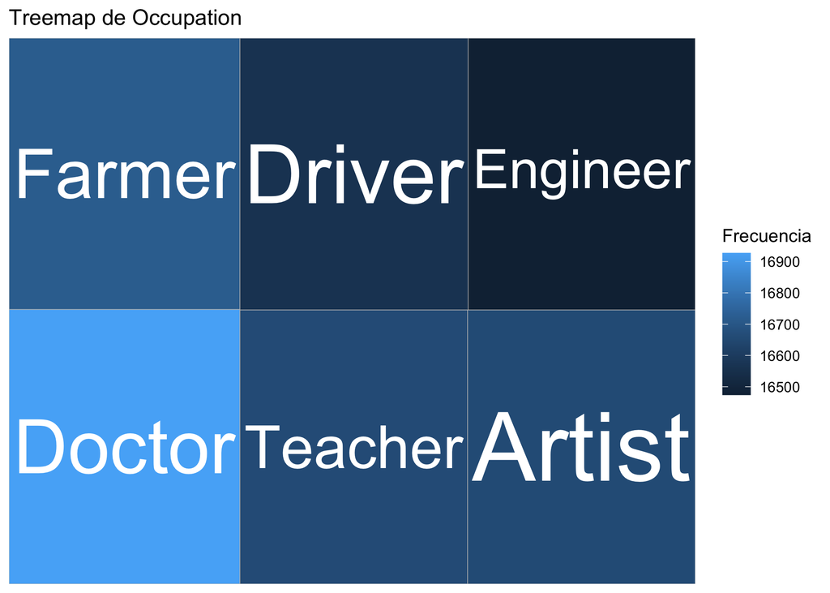

```r
if(!requireNamespace("treemapify", quietly = TRUE)) {
  # opcional: instalar en entorno local si falta
  # install.packages("treemapify")
}
if("occupation" %in% names(df) && require(treemapify)) {
  df %>%
    count(occupation) %>%
    filter(!is.na(occupation)) %>%
    ggplot(aes(area = n, fill = n, label = occupation)) +
    geom_treemap() +
    geom_treemap_text(reflow = TRUE, colour = "white", place = "centre", grow = TRUE) +
    labs(title = "Treemap de Occupation", fill = "Frecuencia") +
    theme_minimal()
}
```

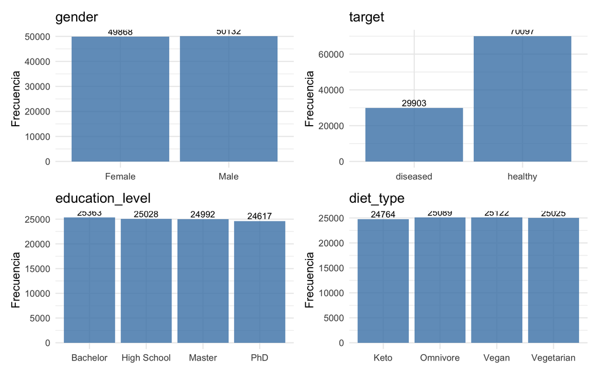

```r
key_cat <- intersect(c("gender","target","education_level","diet_type"), names(df))
plot_list <- map(key_cat, ~{
  ggplot(df, aes(x = .data[[.x]])) +
    geom_bar(fill = "steelblue", alpha = 0.8) +
    geom_text(stat = "count", aes(label = after_stat(count)), vjust = -0.3, size = 3) +
    labs(title = .x, x = NULL, y = "Frecuencia") +
    theme_minimal()
})
wrap_plots(plotlist = plot_list)
```

```r
if(all(c("gender","target") %in% names(df))) {
  tab_gt <- df %>% filter(!is.na(gender), !is.na(target)) %>% count(gender, target) %>% group_by(gender) %>% mutate(pct = round(100*n/sum(n),1))
  tab_gt %>% render_table(caption = "Tabla de contingencia: gender x target")
  # Chi-cuadrado y Cramer's V
  chi_tab <- table(df$gender, df$target)
  chi_obj <- suppressWarnings(chisq.test(chi_tab))
  cramer <- effectsize::cramers_v(chi_tab)
  cat("\nChi-cuadrado:", round(chi_obj$statistic,3), "(gl=", chi_obj$parameter, ") p=", signif(chi_obj$p.value,3), "\n")
  cat("Cramer's V:", round(cramer$Cramers_v,3), "Magnitud:", cramer$Magnitude, "\n")
}
```

```
##
## Chi-cuadrado: 0.08 (gl= 1 ) p= 0.777
## Cramer's V: 0 Magnitud:
```

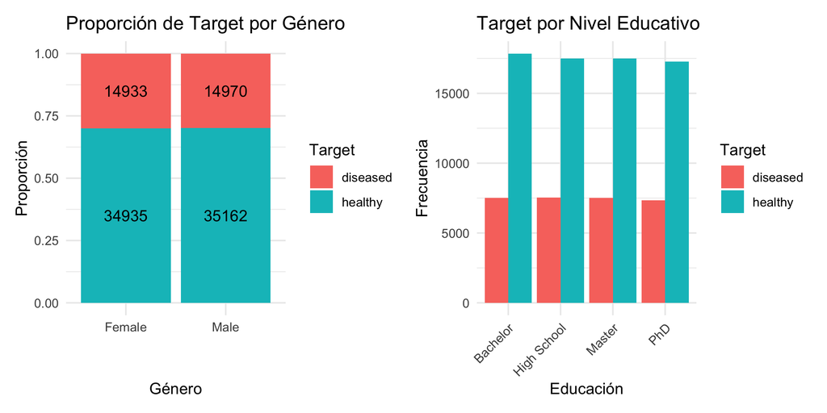

```r
# Gráfico de barras apiladas
if(all(c("gender","target") %in% names(df))) {
  p_stacked <- df %>% filter(!is.na(gender), !is.na(target)) %>%
    ggplot(aes(x = gender, fill = target)) +
    geom_bar(position = "fill") +
    geom_text(stat = "count", aes(label = after_stat(count)), position = position_fill(vjust = 0.5)) +
    labs(title = "Proporción de Target por Género", x = "Género", y = "Proporción", fill = "Target") +
    theme_minimal()

  # Si hay education_level, hacer otro bivariado
  if("education_level" %in% names(df)) {
    p_education <- df %>% filter(!is.na(education_level), !is.na(target)) %>%
      ggplot(aes(x = education_level, fill = target)) +
      geom_bar(position = "dodge") +
      labs(title = "Target por Nivel Educativo", x = "Educación", y = "Frecuencia", fill = "Target") +
      theme_minimal() +
      theme(axis.text.x = element_text(angle = 45, hjust = 1))

    p_stacked + p_education
  } else {
    p_stacked
  }
}
```

# 6 6. Análisis Descriptivo de Variables Cuantitativas

```r
num_vars <- setdiff(num_vars, c("survey_code"))
desc_tbl <- df %>% select(any_of(num_vars)) %>% psych::describe() %>% as.data.frame() %>% rownames_to_column("variable") %>% select(variable, n, mean, sd, median, min, max, skew, kurtosis)
desc_tbl %>%
  filter(variable %in% c("age","bmi","height","weight","sleep_hours","daily_steps")) %>%
  render_table(caption = "Estadígrafos variables clave (básicos)", html_font_size = 9)
```

Estadígrafos variables clave (básicos)

| variable | n | mean | sd | median | min | max | skew | kurtosis |
| --- | --- | --- | --- | --- | --- | --- | --- | --- |
| age | 100000 | 48.525990 | 17.886768 | 48.000000 | 18.000000 | 79.00000 | 0.0012578 | -1.2012359 |
| height | 100000 | 170.023707 | 9.982798 | 170.016778 | 140.000000 | 210.00000 | 0.0089420 | -0.0269878 |
| weight | 100000 | 70.064862 | 14.693667 | 69.924141 | 40.000000 | 139.25089 | 0.1288708 | -0.2507124 |
| bmi | 100000 | 24.493876 | 5.951069 | 24.156734 | 9.988494 | 59.23479 | 0.4206923 | 0.2137246 |
| sleep_hours | 100000 | 7.002008 | 1.496821 | 6.998164 | 3.000000 | 12.00000 | 0.0251318 | -0.1227913 |
| daily_steps | 91671 | 7012.925748 | 2488.989356 | 7004.285450 | 1000.000000 | 18064.96954 | 0.0524075 | -0.1437885 |

```r
mode_vec <- function(x){ux <- na.omit(unique(x)); ux[which.max(tabulate(match(x, ux)))]}
num_extended <- df %>% select(any_of(num_vars)) %>% pivot_longer(everything(), names_to="variable", values_to="value") %>% group_by(variable) %>% summarise(
  n = sum(!is.na(value)),
  mean = mean(value, na.rm=TRUE),
  median = median(value, na.rm=TRUE),
  mode = mode_vec(value),
  sd = sd(value, na.rm=TRUE),
  iqr = IQR(value, na.rm=TRUE),
  p10 = quantile(value,0.10, na.rm=TRUE),
  p25 = quantile(value,0.25, na.rm=TRUE),
  p75 = quantile(value,0.75, na.rm=TRUE),
  p90 = quantile(value,0.90, na.rm=TRUE),
  skew = psych::skew(value, na.rm=TRUE),
  kurt = psych::kurtosi(value, na.rm=TRUE)
)
num_extended %>%
  filter(variable %in% c("age","bmi","sleep_hours","daily_steps")) %>%
  render_table(caption="Estadísticos extendidos (forma y posición)", html_font_size = 9)
```

Estadísticos extendidos (forma y posición)

| variable | n | mean | median | mode | sd | iqr | p10 | p25 | p75 | p90 | skew | kurt |
| --- | --- | --- | --- | --- | --- | --- | --- | --- | --- | --- | --- | --- |
| age | 100000 | 48.525990 | 48.000000 | 71.00000 | 17.886768 | 31.000000 | 24.000000 | 33.000000 | 64.000000 | 73.000000 | 0.0012578 | -1.2012359 |
| bmi | 100000 | 24.493876 | 24.156734 | 20.40816 | 5.951069 | 7.987291 | 17.000839 | 20.271405 | 28.258696 | 32.316226 | 0.4206923 | 0.2137246 |
| daily_steps | 91671 | 7012.925748 | 7004.285450 | 1000.00000 | 2488.989356 | 3381.422923 | 3785.179486 | 5320.858377 | 8702.281301 | 10215.523575 | 0.0524075 | -0.1437885 |
| sleep_hours | 100000 | 7.002008 | 6.998164 | 3.00000 | 1.496821 | 2.032438 | 5.071756 | 5.986781 | 8.019219 | 8.922488 | 0.0251318 | -0.1227913 |

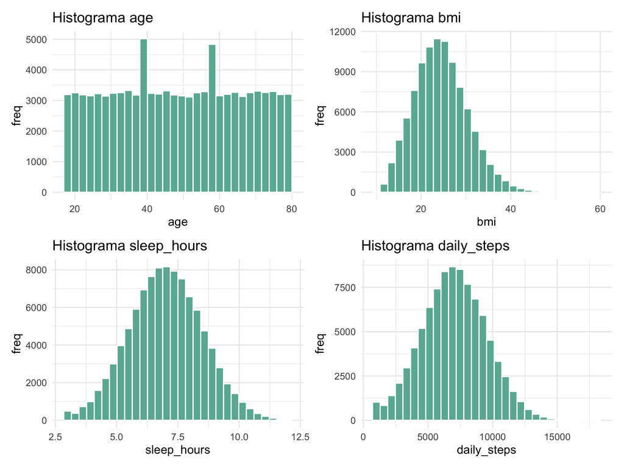

```r
vars_plot <- intersect(c("age","bmi","sleep_hours","daily_steps"), names(df))
plots_h <- map(vars_plot, ~{
  ggplot(df, aes(x = .data[[.x]])) +
    geom_histogram(bins = 30, fill = "#69b3a2", color = "white") +
    labs(title = paste("Histograma", .x), x = .x, y = "freq") +
    theme_minimal()
})
wrap_plots(plotlist = plots_h)
```

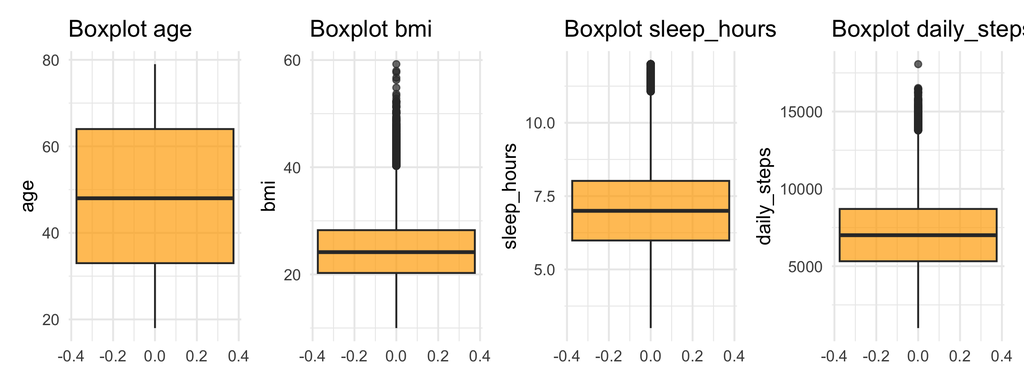

```r
plots_b <- map(vars_plot, ~{
  ggplot(df, aes(y = .data[[.x]])) +
    geom_boxplot(fill = "#ffab00", alpha = 0.7) +
    labs(title = paste("Boxplot", .x), y = .x) +
    theme_minimal()
})
wrap_plots(plotlist = plots_b, ncol = length(plots_b))
```

# 7 7. Correlaciones

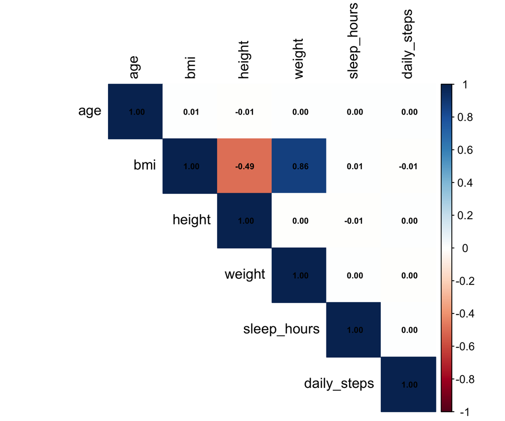

```r
cor_vars <- intersect(c("age","bmi","height","weight","sleep_hours","daily_steps"), names(df))
cmat <- cor(df[cor_vars], use = "complete.obs")
corrplot(cmat, method = "color", type = "upper", addCoef.col = "black", tl.col = "black", number.cex = 0.6)
```

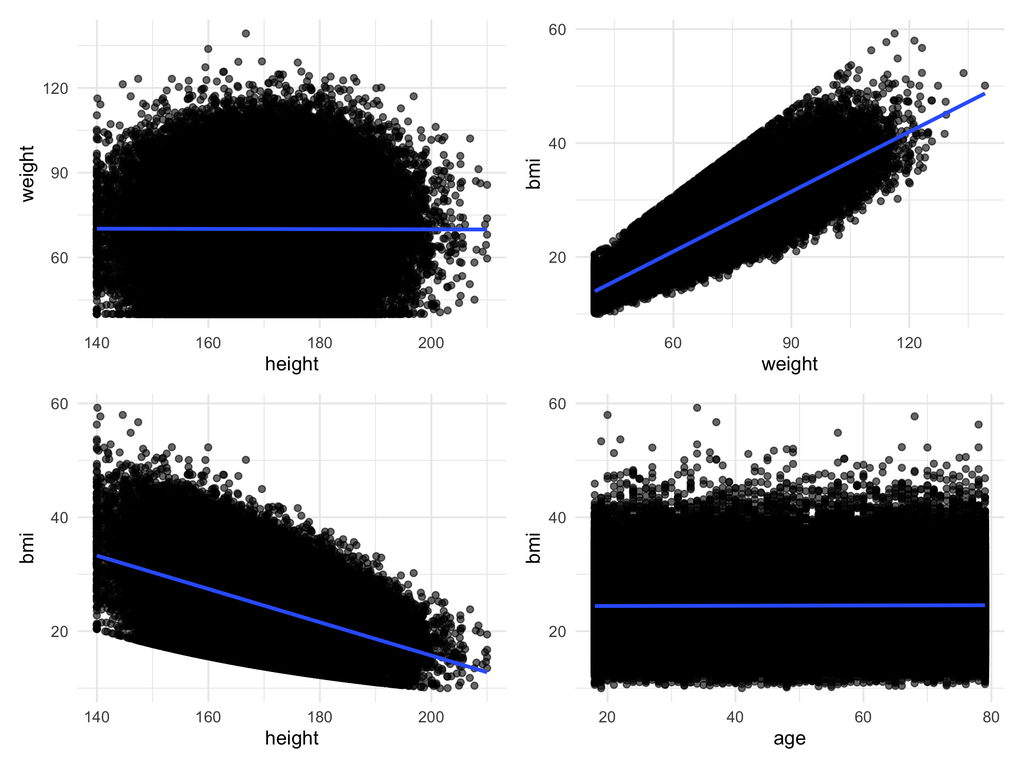

```r
# Diagramas de dispersión para correlaciones altas
if(all(c("height","weight","bmi","age") %in% names(df))) {
  p1 <- ggplot(df, aes(x = height, y = weight)) + geom_point(alpha = 0.6) + geom_smooth(method = "lm", se = FALSE) + theme_minimal()
  p2 <- ggplot(df, aes(x = weight, y = bmi)) + geom_point(alpha = 0.6) + geom_smooth(method = "lm", se = FALSE) + theme_minimal()
  p3 <- ggplot(df, aes(x = height, y = bmi)) + geom_point(alpha = 0.6) + geom_smooth(method = "lm", se = FALSE) + theme_minimal()
  p4 <- ggplot(df, aes(x = age, y = bmi)) + geom_point(alpha = 0.6) + geom_smooth(method = "lm", se = FALSE) + theme_minimal()
  (p1 + p2) / (p3 + p4)
}
```

## 7.1 6.1 Análisis Distribucional

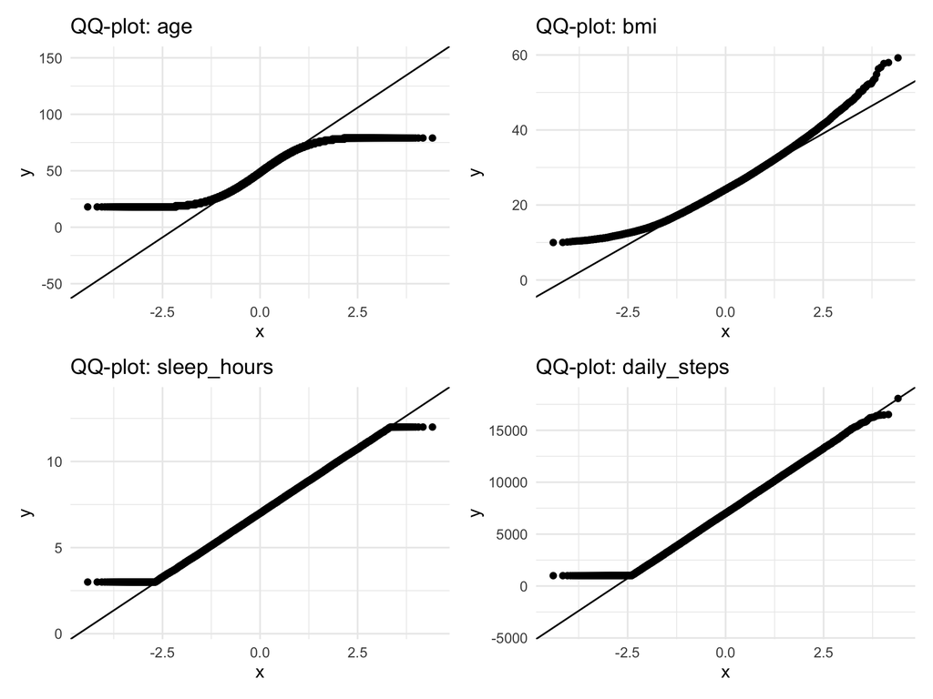

```r
# QQ-plots para evaluar normalidad
key_vars <- intersect(c("age","bmi","sleep_hours","daily_steps"), names(df))
qq_plots <- map(key_vars, ~{
  ggplot(df, aes(sample = .data[[.x]])) +
    stat_qq() + stat_qq_line() +
    labs(title = paste("QQ-plot:", .x)) +
    theme_minimal()
})
wrap_plots(plotlist = qq_plots)
```

```r
# Tests de normalidad
normality_results <- map_df(key_vars, ~{
  if(.x %in% names(df)) {
    vec <- df %>% filter(!is.na(.data[[.x]])) %>% pull(.data[[.x]])
    if(length(vec) > 5000) vec <- sample(vec, 5000)
    sw_test <- shapiro.test(vec)
    data.frame(variable = .x, shapiro_w = sw_test$statistic, shapiro_p = sw_test$p.value)
  }
})
normality_results %>% render_table(caption = "Tests de Normalidad (Shapiro-Wilk)")
```

Tests de Normalidad (Shapiro-Wilk)

|  | variable | shapiro_w | shapiro_p |
| --- | --- | --- | --- |
| W…1 | age | 0.9550999 | 0.0000000 |
| W…2 | bmi | 0.9894079 | 0.0000000 |
| W…3 | sleep_hours | 0.9989825 | 0.0038962 |
| W…4 | daily_steps | 0.9981960 | 0.0000157 |

```r
dist_suggestions <- num_extended %>% filter(variable %in% c("age","bmi","sleep_hours","daily_steps")) %>% mutate(
  sugerida = case_when(
    abs(skew) < 0.3 & abs(kurt) < 1 ~ "Normal",
    skew > 0.8 ~ "Gamma / Log-normal",
    skew > 0.3 & skew <= 0.8 ~ "Asimetría leve (aprox. Normal tras transf.)",
    TRUE ~ "Revisar visual"
  )
) %>% select(variable, skew, kurt, sugerida)
dist_suggestions %>% render_table(caption="Sugerencias distribucionales basadas en forma", html_font_size = 9)
```

Sugerencias distribucionales basadas en forma

| variable | skew | kurt | sugerida |
| --- | --- | --- | --- |
| age | 0.0012578 | -1.2012359 | Revisar visual |
| bmi | 0.4206923 | 0.2137246 | Asimetría leve (aprox. Normal tras transf.) |
| daily_steps | 0.0524075 | -0.1437885 | Normal |
| sleep_hours | 0.0251318 | -0.1227913 | Normal |

# 8 8. Análisis Mixto (Cuantitativas vs Categóricas)

```r
if(all(c("bmi","gender") %in% names(df))) {
  bmi_gender_stats <- df %>% filter(!is.na(bmi), !is.na(gender)) %>% group_by(gender) %>% summarise(n = n(), mean = mean(bmi), sd = sd(bmi), median = median(bmi), q1 = quantile(bmi,0.25), q3 = quantile(bmi,0.75), .groups = "drop")
  bmi_gender_stats %>% render_table(caption = "BMI por género")
}
```

BMI por género

| gender | n | mean | sd | median | q1 | q3 |
| --- | --- | --- | --- | --- | --- | --- |
| Female | 49868 | 24.52000 | 5.925752 | 24.20467 | 20.30653 | 28.26678 |
| Male | 50132 | 24.46789 | 5.976092 | 24.11126 | 20.22856 | 28.24639 |

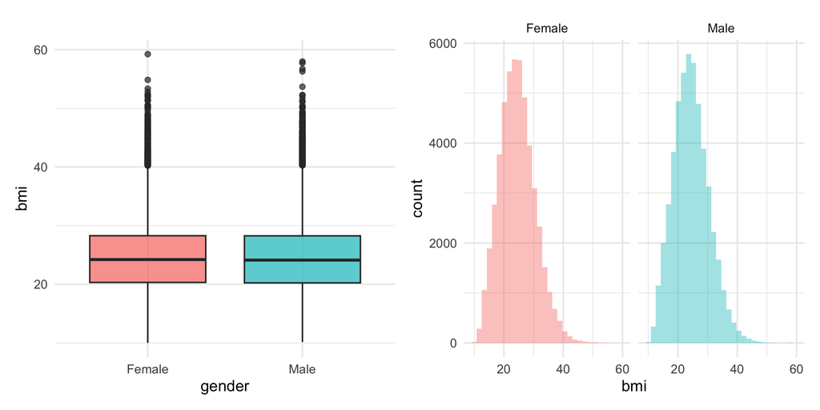

```r
if(all(c("bmi","gender") %in% names(df))) {
  p_box <- ggplot(df, aes(x = gender, y = bmi, fill = gender)) + geom_boxplot(alpha = 0.7) + theme_minimal() + theme(legend.position = "none")
  p_hist <- ggplot(df, aes(x = bmi, fill = gender)) + geom_histogram(position = "identity", alpha = 0.4, bins = 30) + facet_wrap(~gender) + theme_minimal() + theme(legend.position = "none")
  p_box + p_hist
}
```

```r
# Análisis adicional: Age por Target si existe
if(all(c("age","target") %in% names(df))) {
  age_target_stats <- df %>% filter(!is.na(age), !is.na(target)) %>%
    group_by(target) %>%
    summarise(n = n(), mean = mean(age), sd = sd(age), median = median(age),
              q1 = quantile(age,0.25), q3 = quantile(age,0.75), .groups = "drop")
  age_target_stats %>% render_table(caption = "Edad por Target")
}
```

Edad por Target

| target | n | mean | sd | median | q1 | q3 |
| --- | --- | --- | --- | --- | --- | --- |
| diseased | 29903 | 48.71635 | 17.88678 | 49 | 33 | 64 |
| healthy | 70097 | 48.44478 | 17.88627 | 48 | 33 | 64 |

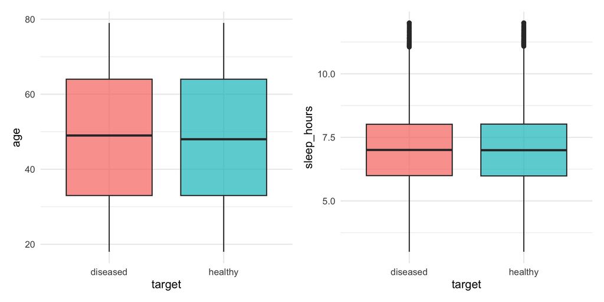

```r
# Gráficos adicionales mixtos
if(all(c("age","target") %in% names(df))) {
  p_age_box <- ggplot(df, aes(x = target, y = age, fill = target)) +
    geom_boxplot(alpha = 0.7) + theme_minimal() + theme(legend.position = "none")

  if("sleep_hours" %in% names(df)) {
    p_sleep_box <- ggplot(df, aes(x = target, y = sleep_hours, fill = target)) +
      geom_boxplot(alpha = 0.7) + theme_minimal() + theme(legend.position = "none")
    p_age_box + p_sleep_box
  } else {
    p_age_box
  }
}
```